# L13: Text as Data

Bogdan G. Popescu

bogdan.popescu@johncabot.edu

Tecnológico de Monterrey

## Introduction

Language underpins nearly all forms of social interaction:

- Laws are codified
- Political events are debated
- Historical narratives are preserved
- People exchange messages

Until recently, analyzing these interactions quantitatively was a challenge.

There are large quantities of text available in the form of *digitized books and texts*

Now, we also have *powerful methods to analyze texts*

## Quantitative Text Analysis

Throughout the rest of the semester, we will use different methods to:

**Assigning numbers to words and documents to measure latent concepts in text.**

So, we want to assign numbers that enable us measure latent concepts from large corpora of text.

**Latent concepts** means that we cannot observe them directly, but rather we have to infer them from observed text.

Thus, we need to find strategies to score words and documents in corpus.

## Examples of Latent Concepts based on Observed Text

Examples:

1. Aggression used in political communication
2. Economic Topics in news articles
3. Hate speech in online comments
4. Ideological position in party manifestos

## Quantitative Text Analysis Techniques

1. **Dictionaries**
- Some words get a score of 1 and others, 0
- Documents get evaluated on whether they include words in the dictionary or not
2. **Supervised Learning**
- Words are assigned weights depending on how they are used across groups
- Documents get evaluated on whether they include words associated with different groups
3. **Text Scaling**
- Words are given weights according to their use across groups
- Documents receive different weights depending on how they use different words
4. **Topic Models**
- Words are assigned a vector of numbers, representing their relevance to a set of topics
- Documents receive a vector of numbers, showing their relevance for specific topics

## Quantitative Text Analysis Techniques

5. **World Embedding Models**
- Words are assigned a vector of numbers, representing the context in which they are used
- Documents are characterised by some average of the vectors of the words they contain

## Applications of Quantitative Text Analysis

1. When did Western Political Thought start diverging from Islamic political thought

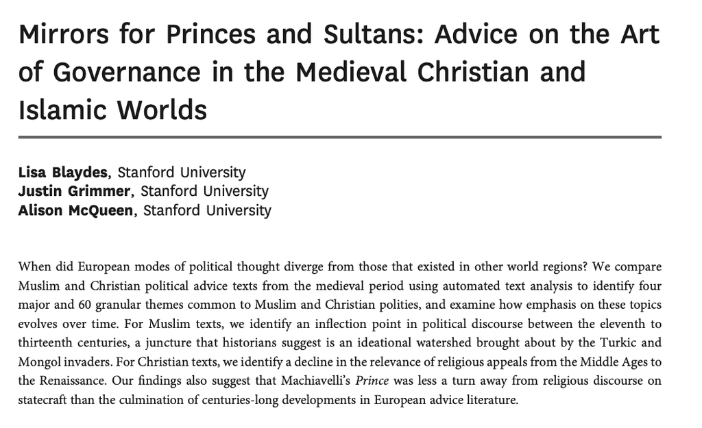

## Applications of Quantitative Text Analysis

1. When did Western Political Thought start diverging from Islamic political thought

2. How do central bankers make decisions on economic policy?

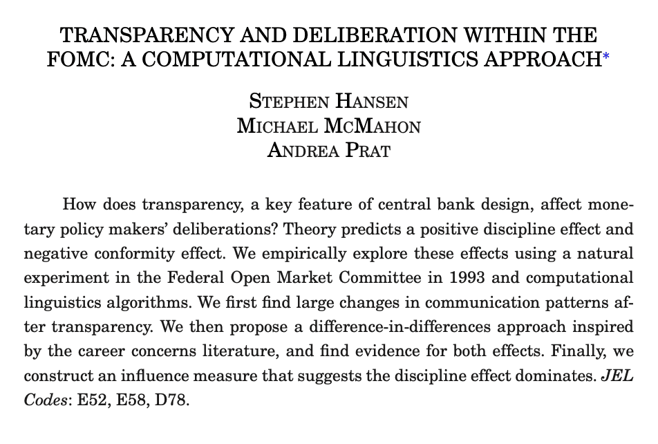

## Applications of Quantitative Text Analysis

1. When did Western Political Thought start diverging from Islamic political thought

2. How do central bankers make decisions on economic policy?

3. How has the cultural meaning of words changed over time?

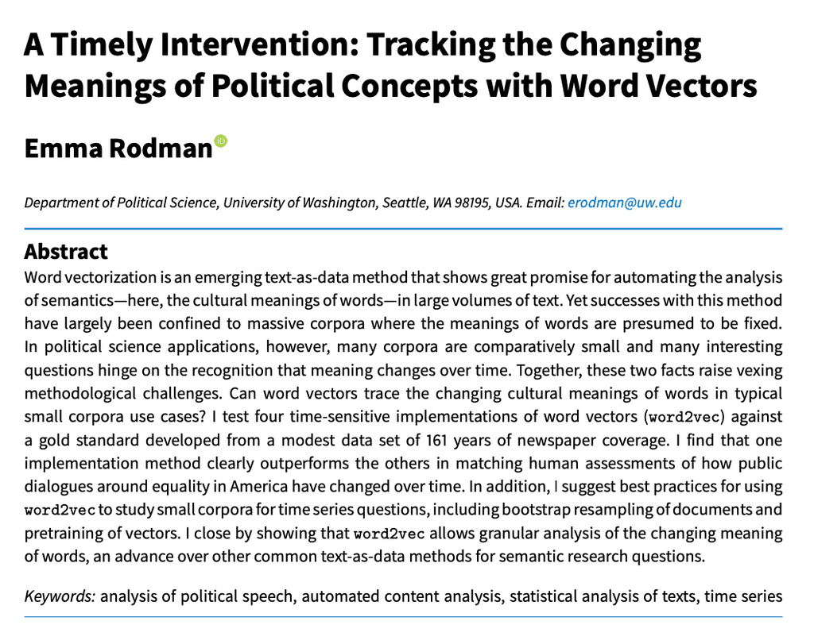

## Applications of Quantitative Text Analysis

1. When did Western Political Thought start diverging from Islamic political thought

2. How do central bankers make decisions on economic policy?

3. How has the cultural meaning of words changed over time?

4. How can we detect online hate speech?

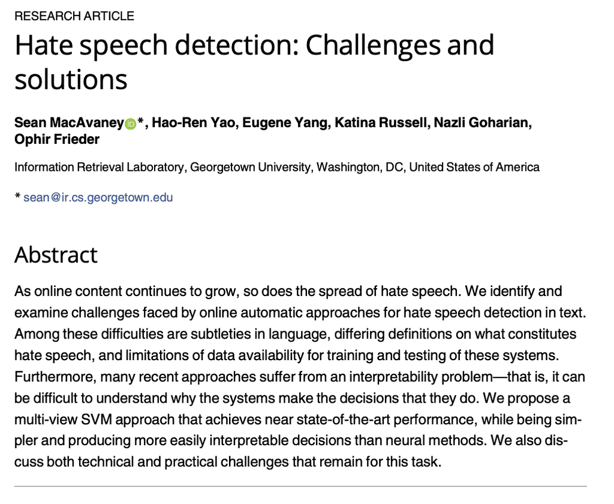

## Applications of Quantitative Text Analysis

1. When did Western Political Thought start diverging from Islamic political thought

2. How do central bankers make decisions on economic policy?

3. How has the cultural meaning of words changed over time?

4. How can we detect online hate speech?

5. Do men and women debate differently?

[figure not shown]

## Other Applications of Quantitative Text Analysis

1. Predicting whether the author of a tweet or text message is young or old
- use of emojis, informal language, length of text
2. Measuring the political content of news
- presence of words related to politics
3. Evaluating how complex texts are
- counting number of syllables, use of adjectives, nouns, and verbs.

## Caveats to Quantitative Text Analysis

**1. Language models are wrong but some are useful**

- Data-generation for language is complex
- We use methods that don’t provide an accurate representation of how data was generated
- Text analysis simplifies multidimensional text and preserves important aspects of meaning

**2. We need to validate text-analysis insights with domain knowledge**

- The methods we use can be applied quickly and on large data
- They could lead to wrong inferences
- It’s important to validate our inferences with out qualitative insights about a domain

## Caveats to Quantitative Text Analysis

**3. We need to combine quantitative and qualitative insights**

- Text analysis is useful for many texts, rather than close readings of few texts
- Text analysis still entails qualitative insights about **how the feature-document matrix** is built
- Text analysis still entails qualitative insights about interpreting statistical outputs

## Stylized Workflow of Text Analysis

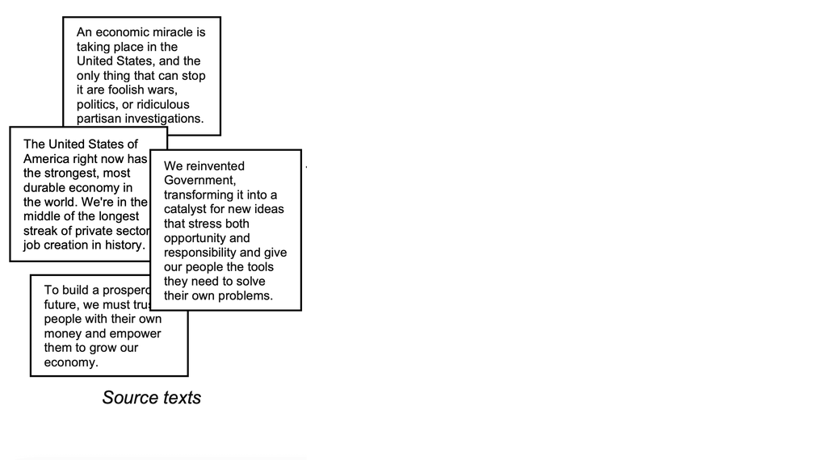

## Stylized Workflow of Text Analysis

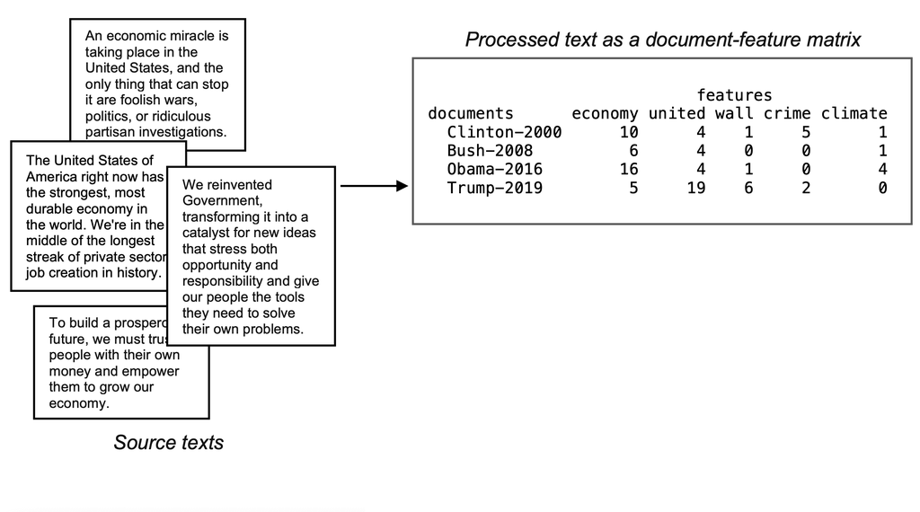

## Stylized Workflow of Text Analysis

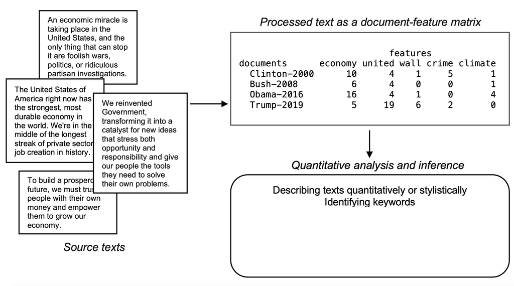

## Stylized Workflow of Text Analysis

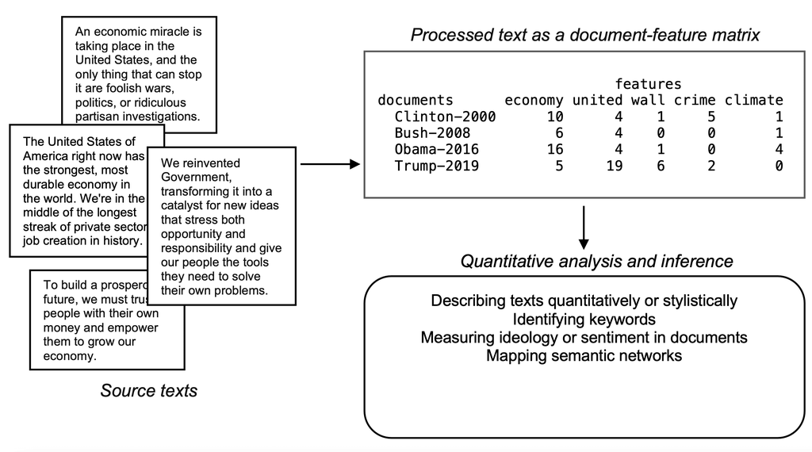

## Stylized Workflow of Text Analysis

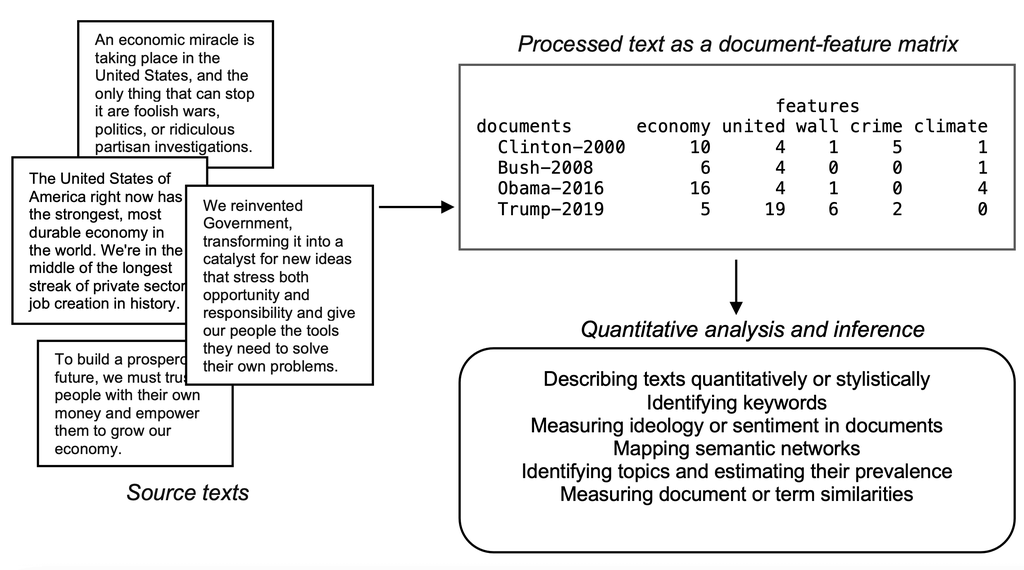

## Stylized Workflow of Text Analysis

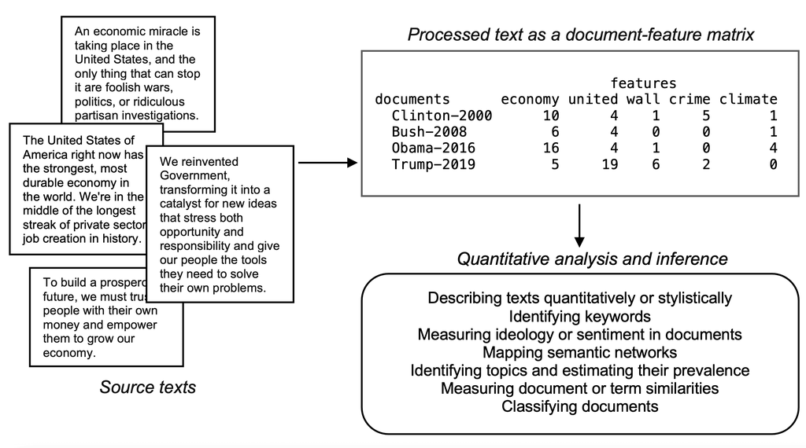

## Detailed Workflow of Text Analysis

Typically, text analysis entails more steps:

1. Deciding on documents: speeches, books, tweets, etc.
2. Digitizing documents (e.g. books, speeches) or Scraping tweets
3. Representing documents in a quantitative way
4. Analyze data
5. Validating the analysis
6. Interpret the result

## Document-feature matrix

A **Document-feature matrix** is a typical way of representing text in a quantitative form

The **rows** of a matrix represent the documents

The **columns** indicate the features (e.g. words).

We need to make decisions about which documents and features are important to build a document-feature matrix.

## Definitions

A **document** is the basic unit of text analysis

A **corpus** is a structured set of documents for analysis

**Tokenization** is the process of breaking down a piece of text, like a sentence or a paragraph, into individual words or “**tokens**.”

## What are documents?

Documents as the basic unit of analysis in text analysis can be:

1. A collection of literary works

[figure not shown]

## What are documents?

Documents as the basic unit of analysis in text analysis can be:

1. A collection of literary works  
2. A novel

[figure not shown]

## What are documents?

Documents as the basic unit of analysis in text analysis can be:

1. A collection of literary works  
2. A novel  
3. A chapter

[figure not shown]

## What are documents?

Documents as the basic unit of analysis in text analysis can be:

1. A collection of literary works  
2. A novel  
3. A chapter  
4. A tweet or a message

[figure not shown]

## What are documents?

Documents as the basic unit of analysis in text analysis can be:

1. A collection of literary works  
2. A novel  
3. A chapter  
4. A tweet or a message  
5. A customer review

[figure not shown]

## What are documents?

Documents as the basic unit of analysis in text analysis can be:

1. A collection of literary works  
2. A novel  
3. A chapter  
4. A tweet or a message  
5. A customer review

What the unit is will depend on your research question.

[figure not shown]

## What are features?

**Features**: Characteristics of text used to analyze and quantify meaning, structure, or style.

**1. Words**

- Simplest feature type
- Individual words can reveal themes, topics, or sentiment (e.g., “exciting,” “boring,” “predictable”)

**2. N-grams**

- **N-grams**: Sequences of N words
  - Example: Bigram (N=2) in “text analysis”
- Useful for identifying phrases or common expressions.

## What are features?

**3. Linguistic Features**

- Analyzes language structure and meaning beyond individual words.
- **Parts of Speech (POS)**
  - Categorizes words (e.g., nouns, verbs, adjectives)
  - Helps identify sentiment words (e.g., “excellent,” “poor”).
- **Named Entities**
  - Recognizes names in text (e.g., people, places, organizations, dates)
  - Useful for extracting key information from large texts.

## What are features?

**3. Linguistic Features**

- Analyzes language structure and meaning beyond individual words.
- **Dependency Parsing**
  - Examines grammatical structure of sentences
  - Identifies relationships like subject, object, and verbs

## Bags of Words

The simplest way of analyzing text is to count words

For each document, we may count how many times each unique words appears

In this context, word order does not matter

Word combinations also do not matter.

Grammar does not matter.

Words are the only relevant features

## Bags of Words Example

**Examples**:

- Sentence 1: “I saw her duck.”
- Sentence 1: “The duck swam across the pond.”

|  | across | duck | her | pond | saw | swam | the |
| --- | --- | --- | --- | --- | --- | --- | --- |
| Sentence 1 | 0 | 1 | 1 | 0 | 1 | 0 | 0 |
| Sentence 2 | 1 | 1 | 0 | 1 | 0 | 1 | 2 |

**What BoW Loses**

- **Context of “duck”**
  - In 1, “duck” means to *lower one’s head.*
  - In 2, “duck” is the animal
- **Meaning of “saw”**
  - With no context, BoW does not distinguish between: saw - the verb and saw - the tool
- **Grammar and Structure**
  - The relationships between words (e.g., “saw her” vs. “her duck”) are lost in BoW.

## Installing Packages in Python

To install packages in Python you always need to do that in terminal.

Search for “terminal” in your operating system.

Then type for example:

```bash
pip install scikit-learn
```

See example below:

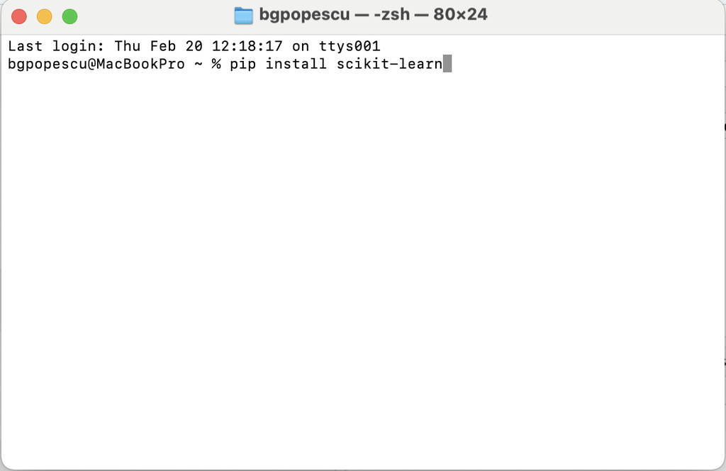

## Installing Packages in R

We install R packages in the following way:

```
R
```

```r
install.packages("ggplot2")
```

This needs to be done in the R console.

If you do this in Quarto, please make sure to remove the `install.packages` command.

## Calling Libraries in Python

This is how we call a library in Python.

```
Python
```

```python
import sklearn
```

We can also import only specific functions from a library

```
Python
```

```python
from sklearn.feature_extraction.text import CountVectorizer
```

## Calling Libraries in Python

In R, we can simply call a library in the following way:

```
R
```

```r
library("ggplot2")
```

or

```
R
```

```r
library(ggplot2)
```

## Bags of Words Example

```
Python
```

```python
import pandas as pd
from sklearn.feature_extraction.text import CountVectorizer

# Assuming `sdg` is a DataFrame with a column 'long_description'
# Example DataFrame creation (skip this if you already have your `sdg` DataFrame)
data = {'long_description': [
  "The quick brown fox jumps over the lazy dog.",
  "Python programming is fun! Let's learn how to code.",
  "In 2024, we will have 50% more data and problems to analyze.",
  "Machine learning is changing how we approach problems in 5 different fields."
]}
sdg = pd.DataFrame(data)

# Convert the 'long_description' column into a list of documents
sdg_corpus = sdg['long_description'].tolist()

# Initialize CountVectorizer for tokenization and DFM creation
vectorizer = CountVectorizer()

# Fit and transform the corpus to create the Document-Feature Matrix (DFM)
sdg_dfm = vectorizer.fit_transform(sdg_corpus)

# Convert to DataFrame for better readability
sdg_dfm_df = pd.DataFrame(sdg_dfm.toarray(), columns=vectorizer.get_feature_names_out())
```

| 2024 | 50 | analyze | and | approach | brown | changing | code | data | different | dog | fields | fox | fun | have | how | in | is | jumps | lazy | learn | learning | let | machine | more | over | problems | programming | python | quick | … |
| --- | --- | --- | --- | --- | --- | --- | --- | --- | --- | --- | --- | --- | --- | --- | --- | --- | --- | --- | --- | --- | --- | --- | --- | --- | --- | --- | --- | --- | --- | --- |
| 0 | 0 | 0 | 0 | 0 | 1 | 0 | 0 | 0 | 0 | 1 | 0 | 1 | 0 | 0 | 0 | 0 | 0 | 1 | 1 | 0 | 0 | 0 | 0 | 0 | 1 | 0 | 0 | 0 | 1 | … |
| 0 | 0 | 0 | 0 | 0 | 0 | 0 | 1 | 0 | 0 | 0 | 0 | 0 | 1 | 0 | 1 | 0 | 1 | 0 | 0 | 1 | 0 | 1 | 0 | 0 | 0 | 0 | 1 | 1 | 0 | … |
| 1 | 1 | 1 | 1 | 0 | 0 | 0 | 0 | 1 | 0 | 0 | 0 | 0 | 0 | 1 | 0 | 1 | 0 | 0 | 0 | 0 | 0 | 0 | 0 | 1 | 0 | 1 | 0 | 0 | 0 | … |
| 0 | 0 | 0 | 0 | 1 | 0 | 1 | 0 | 0 | 1 | 0 | 1 | 0 | 0 | 0 | 1 | 1 | 1 | 0 | 0 | 0 | 1 | 0 | 1 | 0 | 0 | 1 | 0 | 0 | 0 | … |

## Bags of words

```
Python
```

```python
# Number of words (features) in the DFM
num_words = sdg_dfm_df.shape[1]
print(f"Number of words: {num_words}")

# Number of documents in the DFM
num_documents = sdg_dfm_df.shape[0]
print(f"Number of documents: {num_documents}")

# Most common features (top 10 words) in the DFM
top_features = sdg_dfm_df.sum().sort_values(ascending=False).head(10)
print("Top 10 most common features:\n", top_features)
```

```
Number of words: 34
```

```
Number of documents: 4
```

```
Top 10 most common features:
 is          2
we          2
to          2
the         2
in          2
how         2
problems    2
machine     1
learn       1
learning    1
dtype: int64
```

## Bags of words

```
Python
```

```python
# Create a DataFrame for top features
top_features_df = pd.DataFrame(top_features).reset_index()
top_features_df.columns = ['word', 'frequency']
```

```
R
```

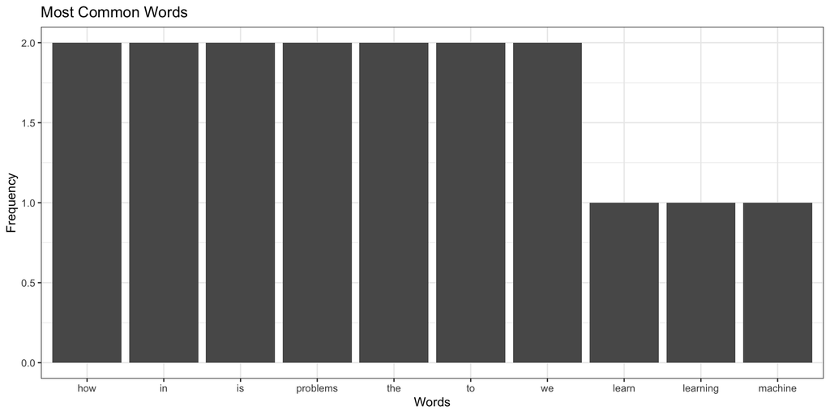

```r
library(reticulate)
library(ggplot2)

df <-  reticulate::py$top_features_df

ggplot(df, aes(x = reorder(word, -frequency), y = frequency)) +
  geom_bar(stat = "identity") +
  labs(title = "Most Common Words", x = "Words", y = "Frequency") +
  theme(axis.text.x = element_text(angle = 45, hjust = 1))+
  theme_bw()
```

## Word sequences/N-grams

N-grams are sequences of words from a document.

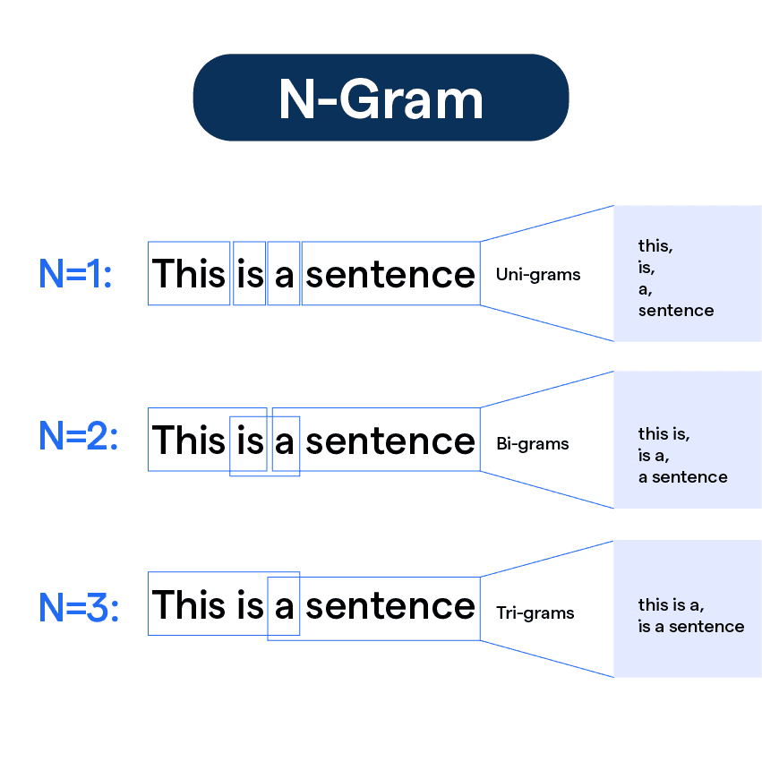

## Word sequences/N-grams

```
Python
```

```python
import nltk
from nltk.tokenize import word_tokenize
from sklearn.feature_extraction.text import CountVectorizer
nltk.download('punkt')

# Convert the 'long_description' column into a list of documents
sdg_corpus = sdg['long_description'].tolist()
sdg_corpus_tokens = [" ".join(word_tokenize(doc.lower())) for doc in sdg_corpus]

# Create a bigram document-feature matrix
vectorizer_bigram = CountVectorizer(ngram_range=(1, 2))
sdg_dfm_bigram = vectorizer_bigram.fit_transform(sdg_corpus_tokens)
sdg_dfm_bigram_df = pd.DataFrame(sdg_dfm_bigram.toarray(), columns=vectorizer_bigram.get_feature_names_out())

# Create a trigram document-feature matrix
vectorizer_trigram = CountVectorizer(ngram_range=(1, 3))
sdg_dfm_trigram = vectorizer_trigram.fit_transform(sdg_corpus_tokens)
sdg_dfm_trigram_df = pd.DataFrame(sdg_dfm_trigram.toarray(), columns=vectorizer_trigram.get_feature_names_out())
```

```
True
```

## Display the Document-Feature Matrix

Remember that our documents are the following:

Document 1: The quick brown fox jumps over the lazy dog.

Document 2: Python programming is fun! Let’s learn how to code.

Document 3: In 2024, we will have 50% more data and problems to analyze.

Document 4: Machine learning is changing how we approach problems in 5 different fields.

## Display the Document-Feature Matrix

We can easily visualize the bigram we produced:

```
Python
```

```python
print(sdg_dfm_bigram_df)
```

| 2024 | 2024 we | 50 | 50 more | analyze | and | and problems | approach | approach problems | brown | brown fox | changing | changing how | code | data | data and | different | different fields | dog | fields | fox | fox jumps | fun | fun let | have | have 50 | how | how to | how we | in | … |
| --- | --- | --- | --- | --- | --- | --- | --- | --- | --- | --- | --- | --- | --- | --- | --- | --- | --- | --- | --- | --- | --- | --- | --- | --- | --- | --- | --- | --- | --- | --- |
| 0 | 0 | 0 | 0 | 0 | 0 | 0 | 0 | 0 | 1 | 1 | 0 | 0 | 0 | 0 | 0 | 0 | 0 | 1 | 0 | 1 | 1 | 0 | 0 | 0 | 0 | 0 | 0 | 0 | 0 | … |
| 0 | 0 | 0 | 0 | 0 | 0 | 0 | 0 | 0 | 0 | 0 | 0 | 0 | 1 | 0 | 0 | 0 | 0 | 0 | 0 | 0 | 0 | 1 | 1 | 0 | 0 | 1 | 1 | 0 | 0 | … |
| 1 | 1 | 1 | 1 | 1 | 1 | 1 | 0 | 0 | 0 | 0 | 0 | 0 | 0 | 1 | 1 | 0 | 0 | 0 | 0 | 0 | 0 | 0 | 0 | 1 | 1 | 0 | 0 | 0 | 1 | … |
| 0 | 0 | 0 | 0 | 0 | 0 | 0 | 1 | 1 | 0 | 0 | 1 | 1 | 0 | 0 | 0 | 1 | 1 | 0 | 1 | 0 | 0 | 0 | 0 | 0 | 0 | 1 | 0 | 1 | 1 | … |

## Display the Document-Feature Matrix

We can easily visualize the trigram we produced:

```
Python
```

```python
print(sdg_dfm_trigram_df)
```

| 2024 | 2024 we | 2024 we will | 50 | 50 more | 50 more data | analyze | and | and problems | and problems to | approach | approach problems | approach problems in | brown | brown fox | brown fox jumps | changing | changing how | changing how we | code | data | data and | data and problems | different | different fields | dog | fields | fox | fox jumps | fox jumps over | … |
| --- | --- | --- | --- | --- | --- | --- | --- | --- | --- | --- | --- | --- | --- | --- | --- | --- | --- | --- | --- | --- | --- | --- | --- | --- | --- | --- | --- | --- | --- | --- |
| 0 | 0 | 0 | 0 | 0 | 0 | 0 | 0 | 0 | 0 | 0 | 0 | 0 | 1 | 1 | 1 | 0 | 0 | 0 | 0 | 0 | 0 | 0 | 0 | 0 | 1 | 0 | 1 | 1 | 1 | … |
| 0 | 0 | 0 | 0 | 0 | 0 | 0 | 0 | 0 | 0 | 0 | 0 | 0 | 0 | 0 | 0 | 0 | 0 | 0 | 1 | 0 | 0 | 0 | 0 | 0 | 0 | 0 | 0 | 0 | 0 | … |
| 1 | 1 | 1 | 1 | 1 | 1 | 1 | 1 | 1 | 1 | 0 | 0 | 0 | 0 | 0 | 0 | 0 | 0 | 0 | 0 | 1 | 1 | 1 | 0 | 0 | 0 | 0 | 0 | 0 | 0 | … |
| 0 | 0 | 0 | 0 | 0 | 0 | 0 | 0 | 0 | 0 | 1 | 1 | 1 | 0 | 0 | 0 | 1 | 1 | 1 | 0 | 0 | 0 | 0 | 1 | 1 | 0 | 1 | 0 | 0 | 0 | … |

## Word sequences/N-grams

```
Python
```

```python
# Print the results
# Column counts
ncol_dfm = sdg_dfm.shape[1]
ncol_bigram = sdg_dfm_bigram.shape[1]
ncol_trigram = sdg_dfm_trigram.shape[1]

print(ncol_dfm, ncol_bigram, ncol_trigram)
```

```
34 71 104
```

## How many words are there in these documents?

```
Python
```

```python
# Convert the 'long_description' column into a list of documents
sdg_corpus = sdg['long_description'].tolist()

# Initialize CountVectorizer for tokenization and DFM creation
vectorizer = CountVectorizer()

# Fit and transform the corpus to create the Document-Feature Matrix (DFM)
sdg_dfm = vectorizer.fit_transform(sdg_corpus)

# Convert to DataFrame for better readability
sdg_dfm_df = pd.DataFrame(sdg_dfm.toarray(), columns=vectorizer.get_feature_names_out())
```

## How many words are there in these documents?

**1. Count the number of words (features) in the DFM**

```
Python
```

```python
num_words = sdg_dfm.shape[1]
num_words
```

```
34
```

**2. Count the number of documents in the DFM**

```
Python
```

```python
num_documents = sdg_dfm.shape[0]
num_documents
```

```
4
```

## How many words are there in these documents?

**3. Find the most common features (top 10)**

```
Python
```

```python
top_features = sdg_dfm_df.sum(axis=0).nlargest(10)
top_features
```

```
how         2
in          2
is          2
problems    2
the         2
to          2
we          2
2024        1
50          1
analyze     1
dtype: int64
```

## Observations based on this Dataset

In our case, we deal with a small corpus

- 4 documents
- 34 unique words
- 34 unique unigrams
- 37 unique bigrams
- 33 unique trigrams

Here is how we know:

```
Python
```

```python
# Find unique 1-grams
unique_unigrams = [col for col in sdg_dfm_df.columns if len(col.split()) == 1]
unique_unigrams
```

```
['2024', '50', 'analyze', 'and', 'approach', 'brown', 'changing', 'code', 'data', 'different', 'dog', 'fields', 'fox', 'fun', 'have', 'how', 'in', 'is', 'jumps', 'lazy', 'learn', 'learning', 'let', 'machine', 'more', 'over', 'problems', 'programming', 'python', 'quick', 'the', 'to', 'we', 'will']
```

## Observations based on this Dataset

In our case, we deal with a small corpus

- 4 documents
- 34 unique words
- 34 unique unigrams
- 37 unique bigrams
- 33 unique trigrams

Here is how we know:

```
Python
```

```python
# Find unique 2-grams
unique_bigrams = [col for col in sdg_dfm_bigram_df.columns if len(col.split()) == 2]
unique_bigrams
```

```
['2024 we', '50 more', 'and problems', 'approach problems', 'brown fox', 'changing how', 'data and', 'different fields', 'fox jumps', 'fun let', 'have 50', 'how to', 'how we', 'in 2024', 'in different', 'is changing', 'is fun', 'jumps over', 'lazy dog', 'learn how', 'learning is', 'let learn', 'mach…
```

## Observations based on this Dataset

In our case, we deal with a small corpus

- 4 documents
- 34 unique words
- 34 unique unigrams
- 37 unique bigrams
- 33 unique trigrams

Here is how we know:

```
Python
```

```python
# Find unique 3-grams
unique_trigrams = [col for col in sdg_dfm_trigram_df.columns if len(col.split()) == 3]
unique_trigrams
```

```
['2024 we will', '50 more data', 'and problems to', 'approach problems in', 'brown fox jumps', 'changing how we', 'data and problems', 'fox jumps over', 'fun let learn', 'have 50 more', 'how to code', 'how we approach', 'in 2024 we', 'in different fields', 'is changing how', 'is fun let', 'jumps ove…
```

## Sparsity

```
Python
```

```python
a = (sdg_dfm_df.to_numpy() == 0).mean()
print(a)
```

```
0.7058823529411765
```

```
Python
```

```python
b = (sdg_dfm_bigram_df.to_numpy() == 0).mean()
print(b)
```

```
0.7288732394366197
```

```
Python
```

```python
c = (sdg_dfm_trigram_df.to_numpy() == 0).mean()
print(c)
```

```
0.7355769230769231
```

However, in most cases we deal with a lot of zeros which means that we will have high sparsity.

## Text Cleaning in Python

Step 1: Turning words to Lowercase  
Step 2: Removing Punctuation  
Step 3: Removing Stopwords  
Step 4: Removing Numbers  
Step 5: Tokenization  
Step 6: Lemmatization  
Step 7: Stemming

## Text Cleaning in Python

### Step1: Turning words to Lowercase

```
Python
```

```python
import string
import re
import nltk
from nltk.tokenize import word_tokenize
# Create a DataFrame
df = pd.DataFrame(sdg_corpus, columns=['document'])
df['document_transformed'] = df['document'].str.lower()
```

| document | document_transformed |
| --- | --- |
| The quick brown fox jumps over the lazy dog. | the quick brown fox jumps over the lazy dog. |
| Python programming is fun! Let's learn how to code. | python programming is fun! let's learn how to code. |
| In 2024, we will have 50% more data and problems to analyze. | in 2024, we will have 50% more data and problems to analyze. |
| Machine learning is changing how we approach problems in 5 different fields. | machine learning is changing how we approach problems in 5 different fields. |

## Text Cleaning in Python

### Step2: Removing Punctuation

This is how we remove punctuation:

```
Python
```

```python
df['document_transformed'] = df['document_transformed'].apply(lambda x: x.translate(str.maketrans('', '', string.punctuation)))
```

| document | document_transformed |
| --- | --- |
| The quick brown fox jumps over the lazy dog. | the quick brown fox jumps over the lazy dog |
| Python programming is fun! Let's learn how to code. | python programming is fun lets learn how to code |
| In 2024, we will have 50% more data and problems to analyze. | in 2024 we will have 50 more data and problems to analyze |
| Machine learning is changing how we approach problems in 5 different fields. | machine learning is changing how we approach problems in 5 different fields |

## Text Cleaning in Python

### Short Digression: `lambda` functions

- Used for short, single-expression functions without a `def`.
- Syntax: `lambda arguments: expression`.
- Best for concise operations; avoid for complex logic.

**Example 1**:

```
Python
```

```python
add = lambda x, y: x + y
print(add(3, 5))  # Output: 8
```

```
8
```

## Text Cleaning in Python

### Short Digression: `lambda` functions

- Used for short, single-expression functions without a `def`.
- Syntax: `lambda arguments: expression`.
- Best for concise operations; avoid for complex logic.

**Example 2**

```
Python
```

```python
df_example = pd.DataFrame({'numbers': [1, 2, 3]})
df_example['squared'] = df_example['numbers'].apply(lambda x: x ** 2)
print(df_example)
```

```
   numbers  squared
0        1        1
1        2        4
2        3        9
```

## Text Cleaning in Python

### Step3: Removing Stopwords

This is how we remove stopwords

```
Python
```

```python
from nltk.corpus import stopwords
stop = stopwords.words('english')
stop
```

```
['a', 'about', 'above', 'after', 'again', 'against', 'ain', 'all', 'am', 'an', 'and', 'any', 'are', 'aren', "aren't", 'as', 'at', 'be', 'because', 'been', 'before', 'being', 'below', 'between', 'both', 'but', 'by', 'can', 'couldn', "couldn't", 'd', 'did', 'didn', "didn't", 'do', 'does', 'doesn', "do…
```

## Text Cleaning in Python

### Step3: Removing Stopwords

This is how we remove stopwords

```
Python
```

```python
df['document_transformed'] = df['document_transformed'].apply(lambda x: ' '.join([word for word in x.split() if word not in (stop)]))
```

| document | document_transformed |
| --- | --- |
| The quick brown fox jumps over the lazy dog. | quick brown fox jumps lazy dog |
| Python programming is fun! Let's learn how to code. | python programming fun lets learn code |
| In 2024, we will have 50% more data and problems to analyze. | 2024 50 data problems analyze |
| Machine learning is changing how we approach problems in 5 different fields. | machine learning changing approach problems 5 different fields |

## Text Cleaning in Python

### Step4: Removing Numbers

```
Python
```

```python
df['document_transformed'] = df['document_transformed'].apply(lambda x: re.sub(r'\d+', '', x))
```

| document | document_transformed |
| --- | --- |
| The quick brown fox jumps over the lazy dog. | quick brown fox jumps lazy dog |
| Python programming is fun! Let's learn how to code. | python programming fun lets learn code |
| In 2024, we will have 50% more data and problems to analyze. | data problems analyze |
| Machine learning is changing how we approach problems in 5 different fields. | machine learning changing approach problems different fields |

## Text Cleaning in Python

### Step5: Tokenization

This is what tokenization looks like:

```
Python
```

```python
df['document_transformed'] = df['document_transformed'].apply(lambda x: ' '.join(word_tokenize(x)))
```

| document | document_transformed |
| --- | --- |
| The quick brown fox jumps over the lazy dog. | quick brown fox jumps lazy dog |
| Python programming is fun! Let's learn how to code. | python programming fun lets learn code |
| In 2024, we will have 50% more data and problems to analyze. | data problems analyze |
| Machine learning is changing how we approach problems in 5 different fields. | machine learning changing approach problems different fields |

## Text Cleaning in Python

### Step6: Lemmatization

**Lemmatization** - algorithmic process of converting words to their lemmas. E.g.: am, are, is → be

This is how we lemmatize the column:

```
Python
```

```python
from nltk.stem import WordNetLemmatizer

# Initialize the lemmatizer
lemmatizer = WordNetLemmatizer()

# Tokenize and lemmatize each document
df['document_transformed'] = df['document_transformed'].apply(lambda x: ' '.join([lemmatizer.lemmatize(x)]))
```

| document | document_transformed |
| --- | --- |
| The quick brown fox jumps over the lazy dog. | quick brown fox jumps lazy dog |
| Python programming is fun! Let's learn how to code. | python programming fun lets learn code |
| In 2024, we will have 50% more data and problems to analyze. | data problems analyze |
| Machine learning is changing how we approach problems in 5 different fields. | machine learning changing approach problems different fields |

## Text Cleaning in Python

### Step7: Stemming

**Stemming** - process for reducing inflected (or sometimes derived) words to their stem, base or root form. Stemmers operate on single words without knowledge of the context.

E.g. production, producer, produce, produces, produced → produc

```
Python
```

```python
from nltk.stem import PorterStemmer
porter_stemmer = PorterStemmer()

df['document_transformed'] = df['document_transformed'].apply(lambda x: ' '.join([porter_stemmer.stem(x)]))
```

| document | document_transformed |
| --- | --- |
| The quick brown fox jumps over the lazy dog. | quick brown fox jumps lazy dog |
| Python programming is fun! Let's learn how to code. | python programming fun lets learn cod |
| In 2024, we will have 50% more data and problems to analyze. | data problems analyz |
| Machine learning is changing how we approach problems in 5 different fields. | machine learning changing approach problems different field |

## Text Cleaning in Python

### Step7: Stemming

```
Python
```

```python
from collections import Counter
# Split each document into words and count the frequency of each word
word_counts = Counter(" ".join(df['document_transformed']).split())

# Convert the word counts to a DataFrame and get the top 10 most frequent words
top_features = pd.DataFrame(word_counts.most_common(10), columns=['word', 'frequency'])
print(top_features)
```

```
          word  frequency
0     problems          2
1        quick          1
2        brown          1
3          fox          1
4        jumps          1
5         lazy          1
6          dog          1
7       python          1
8  programming          1
9          fun          1
```

## Text Cleaning in Python

### Step7: Stemming

**Cleaned**

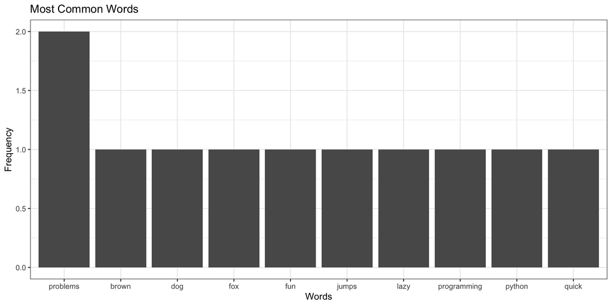

```r
df <-  reticulate::py$top_features

ggplot(df, aes(x = reorder(word, -frequency), y = frequency)) +
  geom_bar(stat = "identity") +
  labs(title = "Most Common Words", x = "Words", y = "Frequency") +
  theme(axis.text.x = element_text(angle = 45, hjust = 1))+
  theme_bw()
```

**Not Cleaned**

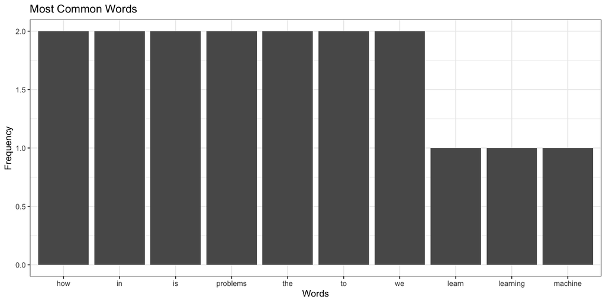

```r
df <-  reticulate::py$top_features_df

ggplot(df, aes(x = reorder(word, -frequency), y = frequency)) +
  geom_bar(stat = "identity") +
  labs(title = "Most Common Words", x = "Words", y = "Frequency") +
  theme(axis.text.x = element_text(angle = 45, hjust = 1))+
  theme_bw()
```

## Deciding on the Cleaning

The optimal representation of a corpus will depend on the particular research task

1. Would you want to remove stop words when trying to detect gendered hate speech?
2. Would you want to stem if you wanted to measure future-oriented language?
3. Would you want to discard rare words when calculating linguistic complexity?

## Conclusion

Quantitative Text Analysis allows us to address a wide variety of important research questions

There is no one right way to represent text for all research questions.

The representation we choose can be consequential for the results we present